# Lab: Wrangling & Distributions in Code

Geometric, binomial, and the normal approximation

## Getting started

```r
library(tidyverse)
library(openintro)
data(nycflights)
```

## Part 1: Wrangling refresher

A few more reps with `nycflights` before new material.

**Try it:**

1. Create a new variable `delayed` that’s `TRUE` if `dep_delay >= 5` and `FALSE` otherwise (hint: `mutate()`).
2. For each `carrier`, find the number of flights and the proportion that were `delayed`. Sort from highest to lowest delay proportion (hint: `group_by()`, `summarise()`, `arrange()`).
3. Do the same thing, but broken down by `carrier` *and* `origin` together.

```r
# TODO: (1) create the delayed variable

# TODO: (2) proportion delayed by carrier, sorted

# TODO: (3) proportion delayed by carrier and origin
```

## Part 2: Geometric and binomial distributions in R

R has built-in functions for every named distribution, following a consistent naming pattern: `d___()` (density/PMF), `p___()` (CDF), `q___()` (inverse CDF / quantile), `r___()` (random draws).

### Geometric distribution

Recall Dr. Smith’s version of the Milgram experiment: probability she finds her *first* refusal on the 3rd person, where $p = 0.35$.

```r
# P(1st and 2nd shock, 3rd refuses) for geometric with p = 0.35
# NOTE: R's dgeom() counts *failures before* the first success, so "3rd person"
# in our lecture's counting corresponds to 2 failures before success in R's parameterization.
dgeom(x = 2, prob = 0.35)
```

```
[1] 0.147875
```

**Try it:** Confirm this matches the by-hand calculation from lecture: $0.65 \times 0.65 \times 0.35$. Then use `dgeom()` to confirm the “10th person” calculation ($0.65^9 \times 0.35$) and the die-rolling practice problem ($(5/6)^5 \times (1/6)$, first 6 on the 6th roll).

```r
# TODO: confirm all three by hand
```

### Binomial distribution

Recall the Gallup obesity example: probability of exactly 8 out of 10 randomly sampled Americans being obese, where $p = 0.262$.

```r
dbinom(x = 8, size = 10, prob = 0.262)
```

```
[1] 0.0005441712
```

**Try it:**

1. Confirm the Milgram 4-person example from lecture: $P(\text{exactly 1 of 4 refuses})$, with $p = 0.35$. Does `dbinom()` match the $0.3844$ we calculated by hand?
2. For the obesity example with $n=100$: confirm the mean ($np$) and SD ($\sqrt{np(1-p)}$) from lecture using R as a calculator.

```r
# TODO: (1) Milgram 4-person example

# TODO: (2) mean and SD for n=100
```

## Part 3: Watching the binomial become normal

Lecture showed this with exact probability calculations. Let’s *simulate* it instead, using `rbinom()` to draw many random binomial outcomes and looking at their distribution.

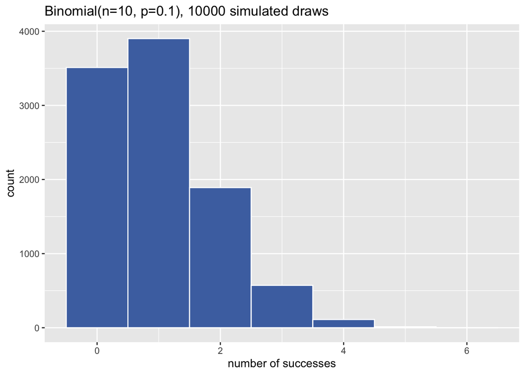

```r
set.seed(2026)

sim_and_plot <- function(n, p, n_sims = 10000) {
  draws <- rbinom(n_sims, size = n, prob = p)
  tibble(x = draws) %>%
    ggplot(aes(x = x)) +
    geom_histogram(binwidth = 1, fill = "#4C72B0", color = "white") +
    labs(title = paste0("Binomial(n=", n, ", p=", p, "), ", n_sims, " simulated draws"),
         x = "number of successes", y = "count")
}

# Same p = 0.10 as the lecture figure, watch the shape change as n grows
sim_and_plot(n = 10, p = 0.10)
```

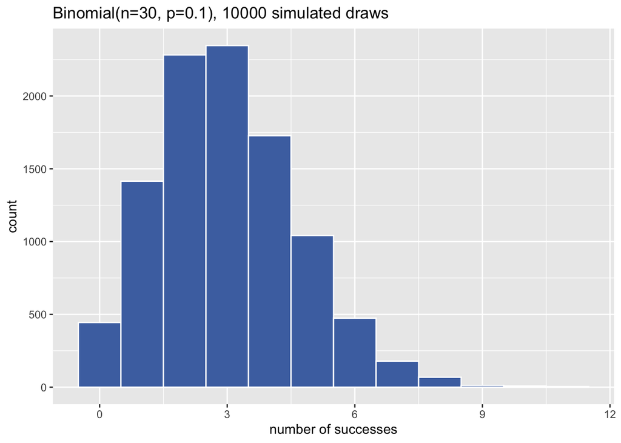

```r
sim_and_plot(n = 30, p = 0.10)
```

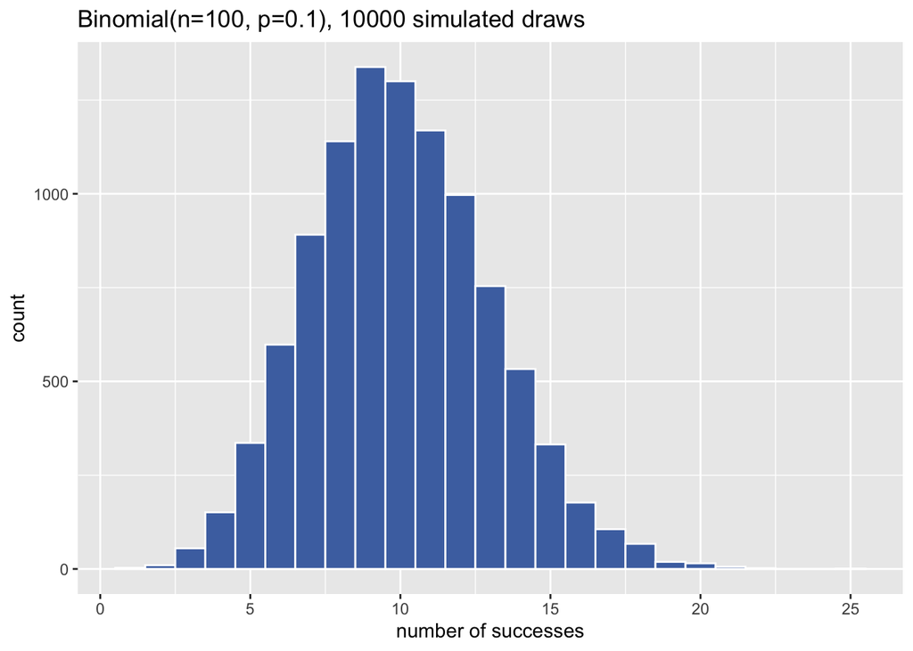

```r
sim_and_plot(n = 100, p = 0.10)
```

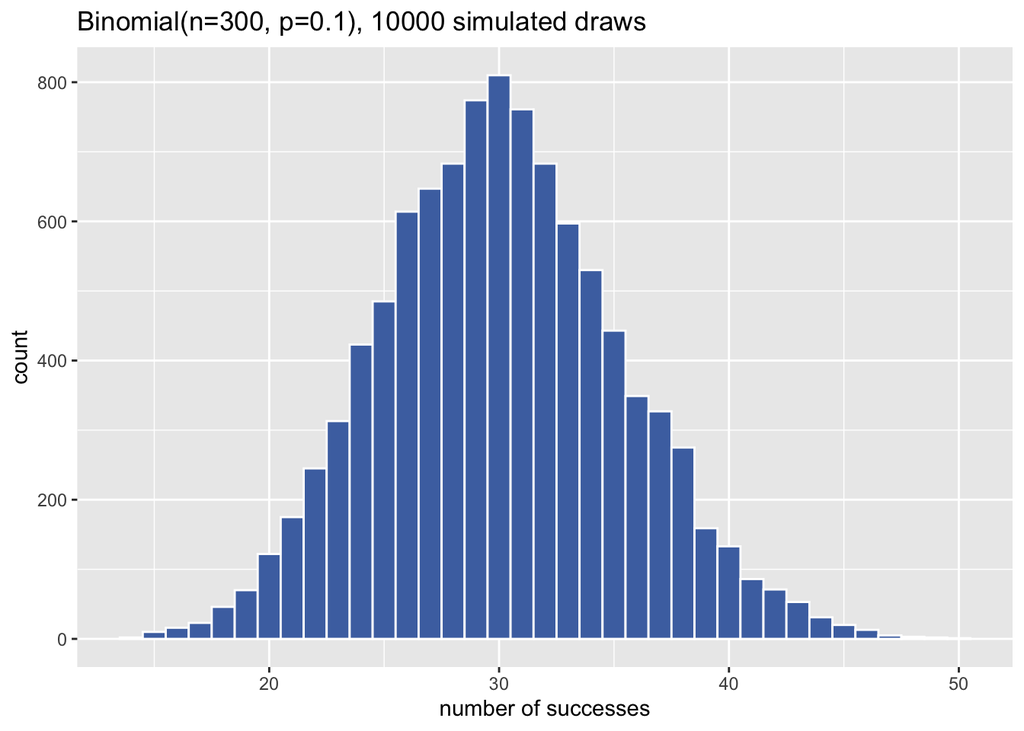

```r
sim_and_plot(n = 300, p = 0.10)
```

**Discuss:** As `n` increases, how does the shape change? Compare what you see at $n=10$ (where $np = 1$, clearly failing the $np \ge 10$ condition) to $n=100$ and $n=300$. At what point would you feel comfortable using a normal approximation?

**Try it:** Try $p = 0.5$ instead of $0.10$, for $n = 10$ and $n = 30$. Does the distribution look normal-ish at a *smaller* $n$ than it did with $p=0.10$? What does this tell you about why the condition checks $n(1-p) \ge 10$ separately from $np \ge 10$, rather than just checking that $n$ is “big enough”?

```r
# TODO: repeat with p = 0.5
```

## Part 4: Putting it together

### Warm-up: recreate the Facebook power-users example

Confirm lecture’s result in code: among 245 Facebook friends, with 25% being “power users,” what’s the probability of 70 or more power-user friends?

```r
# TODO: normal approximation (mu, sigma, z, and 1 - pnorm(z))

# TODO: compare to the exact answer using 1 - pbinom(69, size = 245, prob = 0.25)
```

How close is the normal approximation to the exact binomial answer? Given what lecture said about continuity corrections, is this a case where you’d expect them to matter much (a wide tail area) or a lot (a narrow range)?

### Applying it to real data — normal approximation with `nycflights`

Using your wrangling from Part 1: pick one `carrier` and treat their departure delays as a binomial-style process (delayed vs. not delayed), using the proportion you calculated earlier as your estimate of $p$.

**Your tasks:**

1. Using your chosen carrier’s `delayed` proportion as $p$ and their number of flights as $n$, check whether the normal approximation conditions ($np \ge 10$, $n(1-p) \ge 10$) are satisfied.
2. If so, use the normal approximation to estimate the probability that *more than* some threshold number of their flights (you choose a reasonable threshold) were delayed. Show your $z$-score calculation.
3. Confirm your normal-approximation answer against the exact binomial probability using `pbinom()`. How close are they?

```r
# TODO: (1) check conditions

# TODO: (2) normal approximation calculation

# TODO: (3) compare to exact pbinom() result
```